# Principal Component Analysis (PCA) - Linear

[scikit-learn Doc](http://scikit-learn.org/stable/modules/decomposition.html#pca)

[scikit-learn Parameters](http://scikit-learn.org/stable/modules/generated/sklearn.decomposition.PCA.html#sklearn.decomposition.PCA)

- Linear dimensionality reduction using Singular Value Decomposition of the data to project it to a lower dimensional space.

1901 by Karl Pearson

- Unsupervised Machine Learning

[Wikipedia](https://en.wikipedia.org/wiki/Principal_component_analysis)

- Statistical procedure that utilise [orthogonal transformation](https://en.wikipedia.org/wiki/Orthogonal_transformation) technology
- Convert possible correlated features (predictors) into linearly uncorrelated features (predictors) called **principal components**
- # of principal components <= number of features (predictors)
- First principal component explains the largest possible variance
- Each subsequent component has the highest variance subject to the restriction that it must be orthogonal to the preceding components.
- A collection of the components are called vectors.
- Sensitive to scaling

**Note:**

- Used in exploratory data analysis (EDA)
- Visualize genetic distance and relatedness between populations.
- Method:
  - Eigenvalue decomposition of a data covariance (or correlation) matrix
  - Singular value decomposition of a data matrix (After mean centering / normalizing ) the data matrix for each attribute.
- Output
  - Component scores, sometimes called **factor scores** (the transformed variable values)
  - **loadings** (the weight)
- Data compression and information preservation
- Visualization
- Noise filtering
- Feature extraction and engineering

```python
import numpy as np
import matplotlib.pyplot as plt
%matplotlib inline
import pandas as pd
import seaborn as sns
sns.set()
```

```python
rnd_num = np.random.RandomState(42)
X = np.dot(rnd_num.rand(2,2), rnd_num.randn(2, 500)).T
```

```python
# this is the transformation from x1->x2
rnd_num.rand(2,2)
```

```
array([[0.70906052, 0.87096912],
       [0.71408693, 0.80172808]])
```

```python
rnd_num.randn(2, 500)
```

[output not shown]

[output cut: 279 more lines]

[output not shown]

```python
rnd_num
```

```
RandomState(MT19937) at 0x2A8E1761268
```

```python
X
```

[output not shown]

[output cut: 445 more lines]

[output not shown]

```python
X.shape
```

```
(500, 2)
```

```python
X[:3,0]
```

```
array([-0.70627503, -0.55081076,  0.02828118])
```

```python
X[:3,1]
```

```
array([-0.56091155, -0.46300858,  0.80133257])
```

```python
X[:, 0] = - X[:, 0]
```

```python
X[:3,0]
```

```
array([ 0.70627503,  0.55081076, -0.02828118])
```

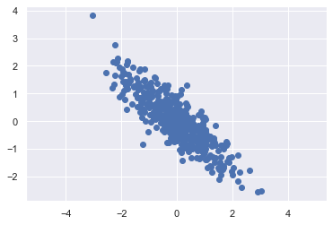

```python
plt.scatter(X[:, 0], X[:, 1]);
plt.axis('equal');
```

## Principal Components Identification

```python
from sklearn.decomposition import PCA
```

```python
pca = PCA(n_components=2)
pca.fit(X)
```

```
PCA(n_components=2)
```

```python
print(pca.components_)
```

```
[[-0.74062812  0.67191517]
 [-0.67191517 -0.74062812]]
```

```python
print(pca.explained_variance_)
```

```
[1.62123504 0.12581594]
```

```python
print(pca.explained_variance_ratio_)
```

```
[0.92798382 0.07201618]
```

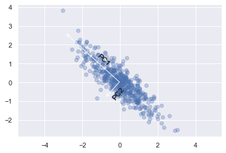

```python
plt.scatter(X[:, 0], X[:, 1], alpha=0.3)


# plot data

for k, v in zip(pca.explained_variance_, pca.components_):
    vec = v * 3 * np.sqrt(k)

    ax = plt.gca()
    arrowprops=dict(arrowstyle='<-',
                    linewidth=1,
                    shrinkA=0, shrinkB=0)
    ax.annotate('', pca.mean_, pca.mean_ + vec, arrowprops=arrowprops)
    ax.text(-0.90, 1.2,'PC1', ha='center', va='center', rotation=-42, size=12)
    ax.text(-0.1,-0.6,'PC2', ha='center', va='center', rotation=50, size=12)
plt.axis('equal');
```

- Two principal components
- Length denotes the significance

This transformation from data axes to principal axes is as an affine transformation, which basically means it is composed of a translation, rotation, and uniform scaling.

```python
###########################################
# 0. prove it is scale depended
```

```python
print(pca.explained_variance_ratio_)
```

```
[0.92798382 0.07201618]
```

```python
X[:, 0] = - X[:, 0]*1000
X[:3,0]
pca = PCA(n_components=2)
pca.fit(X)
print(pca.explained_variance_ratio_)
```

```
[9.99999772e-01 2.27881247e-07]
```

```python
# 1. think of two vectors/signals that could be orthogonal to each other
```

```python
# cos(x) = sin(x+90)
```

```python
#########################################################
```

## Dimensionality Reduction with PCA

```python
rnd_num = np.random.RandomState(42)
X = np.dot(rnd_num.rand(2,2), rnd_num.randn(2, 500)).T
X[:, 0] = - X[:, 0]
```

```python
pca = PCA(n_components=1)
pca.fit(X)
X_pca = pca.transform(X)
```

```python
X.shape
```

```
(500, 2)
```

```python
X_pca.shape
```

```
(500, 1)
```

```python
print(pca.explained_variance_ratio_)
```

```
[0.92798382]
```

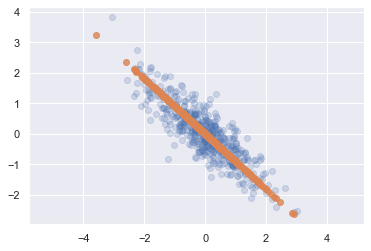

```python
X_new = pca.inverse_transform(X_pca)
plt.scatter(X[:, 0], X[:, 1], alpha=0.2);
plt.scatter(X_new[:, 0], X_new[:, 1], alpha=0.8)
plt.axis('equal');
```

```python
X_pca[:10]
```

```
array([[-0.93904694],
       [-0.75812324],
       [ 0.52029852],
       [-0.40463534],
       [-0.34652686],
       [-0.54106101],
       [-0.09632464],
       [-0.45291152],
       [-0.11731529],
       [-2.51493704]])
```

```python
####################
# 1. load iris data from seaborn
# 2. investigate shortly the dataframe
```

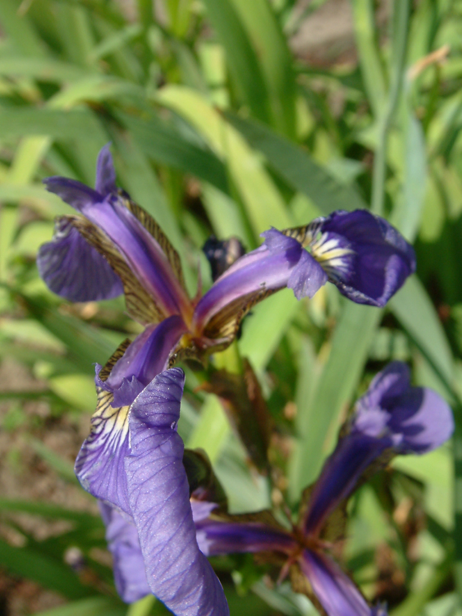

```python
# The Iris Setosa
from IPython.display import Image
url = 'http://upload.wikimedia.org/wikipedia/commons/5/56/Kosaciec_szczecinkowaty_Iris_setosa.jpg'
Image(url,width=300, height=300)
```

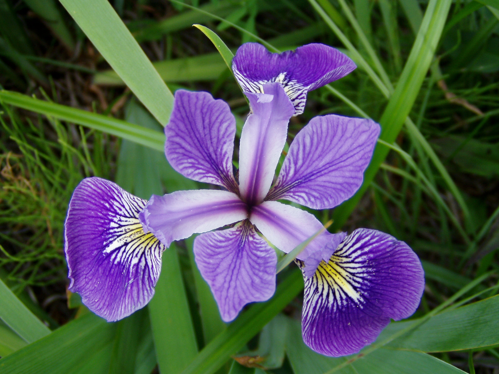

```python
# The Iris Versicolor
from IPython.display import Image
url = 'http://upload.wikimedia.org/wikipedia/commons/4/41/Iris_versicolor_3.jpg'
Image(url,width=300, height=300)
```

```python
import pandas as pd
import matplotlib.pyplot as plt
import seaborn as sb
```

```python
import seaborn as sns
iris = sns.load_dataset('iris')
```

```python
iris.head()
```

|  | sepal_length | sepal_width | petal_length | petal_width | species |
| --- | --- | --- | --- | --- | --- |
| 0 | 5.1 | 3.5 | 1.4 | 0.2 | setosa |
| 1 | 4.9 | 3.0 | 1.4 | 0.2 | setosa |
| 2 | 4.7 | 3.2 | 1.3 | 0.2 | setosa |
| 3 | 4.6 | 3.1 | 1.5 | 0.2 | setosa |
| 4 | 5.0 | 3.6 | 1.4 | 0.2 | setosa |

```python
iris.info()
```

```
<class 'pandas.core.frame.DataFrame'>
RangeIndex: 150 entries, 0 to 149
Data columns (total 5 columns):
 #   Column        Non-Null Count  Dtype
---  ------        --------------  -----
 0   sepal_length  150 non-null    float64
 1   sepal_width   150 non-null    float64
 2   petal_length  150 non-null    float64
 3   petal_width   150 non-null    float64
 4   species       150 non-null    object
dtypes: float64(4), object(1)
memory usage: 6.0+ KB
```

```python
iris.describe()
```

|  | sepal_length | sepal_width | petal_length | petal_width |
| --- | --- | --- | --- | --- |
| count | 150.000000 | 150.000000 | 150.000000 | 150.000000 |
| mean | 5.843333 | 3.057333 | 3.758000 | 1.199333 |
| std | 0.828066 | 0.435866 | 1.765298 | 0.762238 |
| min | 4.300000 | 2.000000 | 1.000000 | 0.100000 |
| 25% | 5.100000 | 2.800000 | 1.600000 | 0.300000 |
| 50% | 5.800000 | 3.000000 | 4.350000 | 1.300000 |
| 75% | 6.400000 | 3.300000 | 5.100000 | 1.800000 |
| max | 7.900000 | 4.400000 | 6.900000 | 2.500000 |

```python
iris.species.value_counts()
```

```
virginica     50
setosa        50
versicolor    50
Name: species, dtype: int64
```

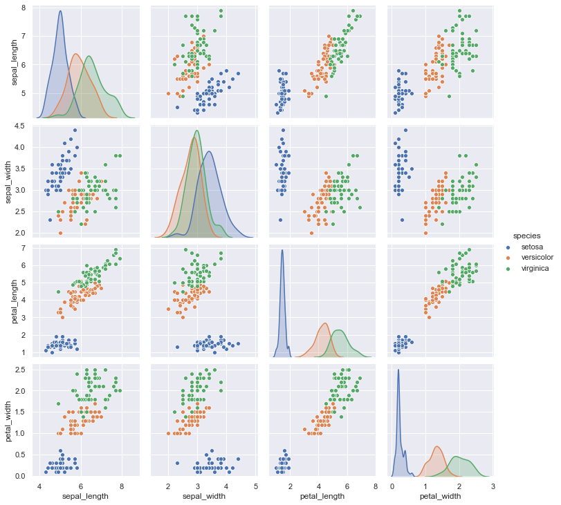

```python
sns.pairplot(iris, hue='species')
```

```python
X = iris.drop('species', axis=1)
y = iris.species
```

```python
from sklearn.model_selection import train_test_split
X_train, X_test, y_train, y_test = train_test_split(X, y, test_size=0.33, random_state=47)
```

```python
# create a NN classifier (MLP) with all the features 1000 iteration, random state 47
```

```python
from sklearn.neural_network import MLPClassifier
model = MLPClassifier(max_iter=1000, random_state=47)
model.fit(X_train, y_train)
y_pred = model.predict(X_test)
from sklearn.metrics import classification_report,confusion_matrix
print(confusion_matrix(y_test,y_pred))
print(classification_report(y_test,y_pred))
ac1 = model.score(X_test, y_test)
ac1
```

```
[[20  0  0]
 [ 0  9  0]
 [ 0  0 21]]
              precision    recall  f1-score   support

      setosa       1.00      1.00      1.00        20
  versicolor       1.00      1.00      1.00         9
   virginica       1.00      1.00      1.00        21

    accuracy                           1.00        50
   macro avg       1.00      1.00      1.00        50
weighted avg       1.00      1.00      1.00        50
```

```
1.0
```

```python
# create a standard scaler, scale the data
```

```python
from sklearn.preprocessing import StandardScaler
scaler = StandardScaler()
scaler.fit(X)
X_scaled = scaler.transform(X)
```

```python
pca = PCA(n_components=4)
pca.fit(X_scaled)
PCA(n_components=4)
rc = X.columns
rp = pca.explained_variance_ratio_
rdata = {'Feature':rc, 'Variance Ratio':rp}
df = pd.DataFrame(rdata)
df
```

|  | Feature | Variance Ratio |
| --- | --- | --- |
| 0 | sepal_length | 0.729624 |
| 1 | sepal_width | 0.228508 |
| 2 | petal_length | 0.036689 |
| 3 | petal_width | 0.005179 |

```python
# 3. what is the expained variance with 1..4 features? plot cumulative plot
```

```python
df.iloc[0,1]
```

```
0.729624454132999
```

```python
df.iloc[0,1]+df.iloc[1,1]
```

```
0.9581320720000164
```

```python
df.iloc[0,1]+df.iloc[1,1]+df.iloc[2,1]
```

```
0.9948212908928451
```

```python
df.iloc[0,1]+df.iloc[1,1]+df.iloc[2,1]+df.iloc[3,1]
```

```
0.9999999999999999
```

```python
X = iris[['sepal_length']]
X_scaled = scaler.fit_transform(X)
X_train, X_test, y_train, y_test = train_test_split(X_scaled, y, test_size=0.33, random_state=47)
model1 = MLPClassifier(max_iter=1000, random_state=47)
model1.fit(X_train, y_train)
y_pred = model1.predict(X_test)
print(confusion_matrix(y_test,y_pred))
print(classification_report(y_test,y_pred))
ac2 = float(model1.score(X_test, y_test))
ac2
```

```
[[14  6  0]
 [ 0  8  1]
 [ 0  8 13]]
              precision    recall  f1-score   support

      setosa       1.00      0.70      0.82        20
  versicolor       0.36      0.89      0.52         9
   virginica       0.93      0.62      0.74        21

    accuracy                           0.70        50
   macro avg       0.76      0.74      0.69        50
weighted avg       0.86      0.70      0.73        50
```

```
0.7
```

```python
X = iris[['sepal_length','sepal_width']]
X_scaled = scaler.fit_transform(X)
X_train, X_test, y_train, y_test = train_test_split(X_scaled, y, test_size=0.33, random_state=47)
model2 = MLPClassifier(max_iter=1000, random_state=47)
model2.fit(X_train, y_train)
y_pred = model2.predict(X_test)
print(confusion_matrix(y_test,y_pred))
print(classification_report(y_test,y_pred))
ac3 = float(model2.score(X_test, y_test))
ac3
```

```
[[20  0  0]
 [ 0  7  2]
 [ 0  8 13]]
              precision    recall  f1-score   support

      setosa       1.00      1.00      1.00        20
  versicolor       0.47      0.78      0.58         9
   virginica       0.87      0.62      0.72        21

    accuracy                           0.80        50
   macro avg       0.78      0.80      0.77        50
weighted avg       0.85      0.80      0.81        50
```

```
0.8
```

```python
X = iris[['sepal_length','sepal_width','petal_length']]
X_scaled = scaler.fit_transform(X)
X_train, X_test, y_train, y_test = train_test_split(X_scaled, y, test_size=0.33, random_state=47)
model3 = MLPClassifier(max_iter=1000, random_state=47)
model3.fit(X_train, y_train)
y_pred = model3.predict(X_test)
print(confusion_matrix(y_test,y_pred))
print(classification_report(y_test,y_pred))
ac4 = float(model3.score(X_test, y_test))
ac4
```

```
[[20  0  0]
 [ 0  9  0]
 [ 0  3 18]]
              precision    recall  f1-score   support

      setosa       1.00      1.00      1.00        20
  versicolor       0.75      1.00      0.86         9
   virginica       1.00      0.86      0.92        21

    accuracy                           0.94        50
   macro avg       0.92      0.95      0.93        50
weighted avg       0.95      0.94      0.94        50
```

```
0.94
```

```python
X = iris[['sepal_length','sepal_width','petal_length','petal_width']]
X_scaled = scaler.fit_transform(X)
X_train, X_test, y_train, y_test = train_test_split(X_scaled, y, test_size=0.33, random_state=47)
model4 = MLPClassifier(max_iter=1000, random_state=47)
model4.fit(X_train, y_train)
y_pred = model4.predict(X_test)
print(confusion_matrix(y_test,y_pred))
print(classification_report(y_test,y_pred))
ac5 = float(model4.score(X_test, y_test))
ac5
```

```
[[20  0  0]
 [ 0  9  0]
 [ 0  1 20]]
              precision    recall  f1-score   support

      setosa       1.00      1.00      1.00        20
  versicolor       0.90      1.00      0.95         9
   virginica       1.00      0.95      0.98        21

    accuracy                           0.98        50
   macro avg       0.97      0.98      0.97        50
weighted avg       0.98      0.98      0.98        50
```

```
0.98
```

```python
models = ['Non-scaled','scaled feature 1 only','scaled features 1+2 only',
          'scaled features 1+2+3 only','scaled features 1+2+3+4 only']
tests_acc = [ac1, ac2, ac3, ac4, ac5]
```

```python
compare_models = pd.DataFrame({ "Algorithms": models, "Tests accuracy": tests_acc })
compare_models.sort_values(by = "Tests accuracy", ascending = False)
```

|  | Algorithms | Tests accuracy |
| --- | --- | --- |
| 0 | Non-scaled | 1.00 |
| 4 | scaled features 1+2+3+4 only | 0.98 |
| 3 | scaled features 1+2+3 only | 0.94 |
| 2 | scaled features 1+2 only | 0.80 |
| 1 | scaled feature 1 only | 0.70 |

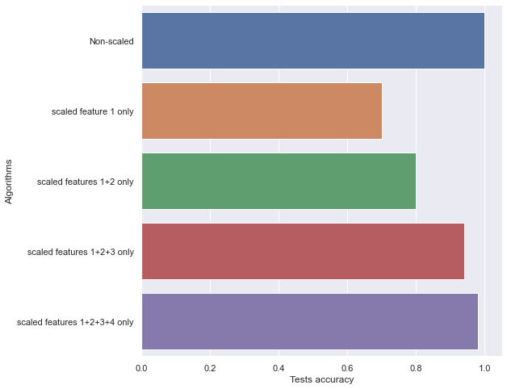

```python
import matplotlib.pyplot as plt
%matplotlib inline
plt.figure(figsize=(8,8))
sns.barplot(x = "Tests accuracy", y = "Algorithms", data = compare_models)
plt.show()
```

```python
import itertools
l = itertools.combinations([1,2,3,4],3)
for i in l:
    print(i)
```

```
(1, 2, 3)
(1, 2, 4)
(1, 3, 4)
(2, 3, 4)
```

```python
iris.columns
```

```
Index(['sepal_length', 'sepal_width', 'petal_length', 'petal_width',
       'species'],
      dtype='object')
```

```python
iris.rename(columns={"sepal_length": "A", "sepal_width": "B", "petal_length": "C", "petal_width": "D"},inplace=True)
```

```python
for i in range(1,5):
    c = itertools.combinations("ABCD",i)
    for item in c:
        ls = list(item)
        X = iris[ls]
        X_scaled = scaler.fit_transform(X)
        X_train, X_test, y_train, y_test = train_test_split(X_scaled, y, test_size=0.33,random_state=47)
        model = MLPClassifier(max_iter=1000, random_state=47)
        model.fit(X_train,y_train)
        score = model.score(X_test,y_test)
        print(ls,score)
```

```
['A'] 0.7
['B'] 0.62
['C'] 0.94
['D'] 0.98
['A', 'B'] 0.8
['A', 'C'] 0.94
['A', 'D'] 0.98
['B', 'C'] 0.96
['B', 'D'] 0.96
['C', 'D'] 0.98
['A', 'B', 'C'] 0.94
['A', 'B', 'D'] 0.96
['A', 'C', 'D'] 0.98
['B', 'C', 'D'] 0.98
['A', 'B', 'C', 'D'] 0.98
```

```python
for i in range(1,5):
    c = itertools.combinations("ABCD",i)
    for item in c:
        ls = list(item)
        X = iris[ls]
        X_train, X_test, y_train, y_test = train_test_split(X, y, test_size=0.33,random_state=47)
        model = MLPClassifier(max_iter=1000, random_state=47)
        model.fit(X_train,y_train)
        score = model.score(X_test,y_test)
        print(ls,score)
```

```
['A'] 0.7
['B'] 0.52
['C'] 0.94
['D'] 0.98
['A', 'B'] 0.82
['A', 'C'] 0.96
['A', 'D'] 0.98
['B', 'C'] 0.96
['B', 'D'] 1.0
['C', 'D'] 0.98
['A', 'B', 'C'] 0.94
['A', 'B', 'D'] 1.0
['A', 'C', 'D'] 1.0
['B', 'C', 'D'] 0.98
['A', 'B', 'C', 'D'] 1.0
```